# Detecting Correct Execution of Barbell Lifts

Jeroen van Zundert

August 22, 2015

Data courtesy of:

Ugulino, W.; Cardador, D.; Vega, K.; Velloso, E.; Milidiu, R.; Fuks, H. Wearable Computing: Accelerometers’ Data Classification of Body Postures and Movements. Proceedings of 21st Brazilian Symposium on Artificial Intelligence. Advances in Artificial Intelligence - SBIA 2012. In: Lecture Notes in Computer Science. , pp. 52-61. Curitiba, PR: Springer Berlin / Heidelberg, 2012. ISBN 978-3-642-34458-9. DOI: 10.1007/978-3-642-34459-6_6.

# Detecting Correct Execution of Barbell Lifts

## Data Processing

The data is obtained from the internet and is available in a csv format.

```r
local_file <- 'pml-training.csv'
if (!exists(local_file)) {
  download.file('https://d396qusza40orc.cloudfront.net/predmachlearn/pml-training.csv', local_file,'wget')
}
training <- read.csv(local_file)

local_file <- 'pml-testing.csv'
if (!exists(local_file)) {
  download.file('https://d396qusza40orc.cloudfront.net/predmachlearn/pml-testing.csv', local_file,'wget')
}
testing <- read.csv(local_file)
```

Remove NA columns and columns 1 to 7 which do not contain relevant data (such as name of the person, time stamp at which exercise was performed, etc)

```r
col_select <- (colSums(is.na(testing))==0) & (colSums(is.na(training))==0)
testing_clean <- testing[, col_select]
testing_clean<-testing_clean[,8:ncol(testing_clean)]

training_clean <- training[ , col_select]
training_clean<-training_clean[,8:ncol(training_clean)]
```

## Prediction

We set the seed and use 2-fold cross-validation to assess the out-of-sample error. Two-fold is sufficient with such a large data set (nearly 20000 observations with only 52 predictors). Also, running time becomes a problem otherwise with more elaborate algorithms.

The algorithm for this problem should be able to make a distinction between 5 classes. Classification tree and random forest algorithms are well suited for this. I start with a simple classification tree to set a benchmark that runs fast:

```r
library(caret)
set.seed(1000)
fitcontrol <- trainControl(method="cv", number=2) # 2-fold cross validation
fit <- train(classe ~., data=training_clean, trControl=fitcontrol,  method="rpart") # train with rpart
print(fit)
```

```
## CART
##
## 19622 samples
##    52 predictors
##     5 classes: 'A', 'B', 'C', 'D', 'E'
##
## No pre-processing
## Resampling: Cross-Validated (2 fold)
## Summary of sample sizes: 9810, 9812
## Resampling results across tuning parameters:
##
##   cp          Accuracy   Kappa       Accuracy SD  Kappa SD
##   0.03567868  0.5231400  0.38861731  0.03704878   0.06499240
##   0.05998671  0.4308872  0.23294913  0.09341638   0.15515565
##   0.11515454  0.3245888  0.06161876  0.05691227   0.08714209
##
## Accuracy was used to select the optimal model using  the largest value.
## The final value used for the model was cp = 0.03567868.
```

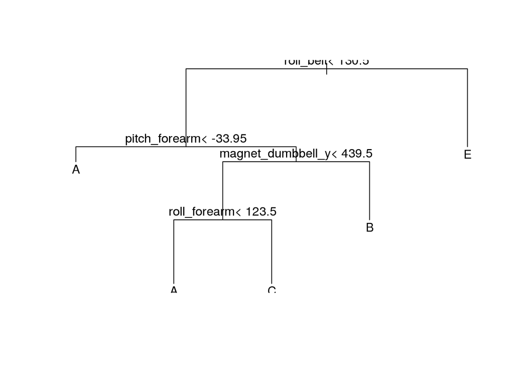

```r
plot(fit$finalModel)
text(fit$finalModel)
```

```r
table(predict(fit), training_clean$classe)
```

```
##
##        A    B    C    D    E
##   A 5080 1581 1587 1449  524
##   B   81 1286  108  568  486
##   C  405  930 1727 1199  966
##   D    0    0    0    0    0
##   E   14    0    0    0 1631
```

The accuracy is 52.3%. The matrix shows that all but class A are very hard to predict for a straightforward classification tree algorithm.

Next I use the random-forest method:

```r
set.seed(1000)
fitcontrol <- trainControl(method="cv", number=2)
fit <- train(classe ~., data=training_clean, trControl=fitcontrol,  method="rf")
print(fit)
```

```
## Random Forest
##
## 19622 samples
##    52 predictors
##     5 classes: 'A', 'B', 'C', 'D', 'E'
##
## No pre-processing
## Resampling: Cross-Validated (2 fold)
## Summary of sample sizes: 9810, 9812
## Resampling results across tuning parameters:
##
##   mtry  Accuracy   Kappa      Accuracy SD  Kappa SD
##    2    0.9891959  0.9863324  0.001728191  0.002184597
##   27    0.9898075  0.9871060  0.002304862  0.002915395
##   52    0.9844057  0.9802698  0.006196018  0.007842496
##
## Accuracy was used to select the optimal model using  the largest value.
## The final value used for the model was mtry = 27.
```

```r
print(fit$finalModel)
```

```
##
## Call:
##  randomForest(x = x, y = y, mtry = param$mtry)
##                Type of random forest: classification
##                      Number of trees: 500
## No. of variables tried at each split: 27
##
##         OOB estimate of  error rate: 0.43%
## Confusion matrix:
##      A    B    C    D    E  class.error
## A 5576    3    0    0    1 0.0007168459
## B   19 3773    5    0    0 0.0063207796
## C    0   10 3402   10    0 0.0058445354
## D    0    0   22 3190    4 0.0080845771
## E    0    1    5    5 3596 0.0030496257
```

What also is interesting are the variables with the most impact:

```r
varImp(fit)
```

```
## rf variable importance
##
##   only 20 most important variables shown (out of 52)
##
##                      Overall
## roll_belt            100.000
## pitch_forearm         58.804
## yaw_belt              53.446
## pitch_belt            43.768
## magnet_dumbbell_y     43.282
## roll_forearm          42.465
## magnet_dumbbell_z     41.985
## accel_dumbbell_y      21.112
## roll_dumbbell         16.871
## accel_forearm_x       16.572
## magnet_dumbbell_x     16.486
## magnet_belt_z         14.801
## total_accel_dumbbell  14.063
## magnet_forearm_z      13.651
## accel_dumbbell_z      13.560
## accel_belt_z          13.506
## magnet_belt_y         11.331
## yaw_arm               10.929
## gyros_belt_z          10.812
## magnet_belt_x          9.576
```

roll_belt is the most important variable, followed by pitch_forearm and yaw_belt.